# Project: Wrangle and Analyze Data

### Test

```python
df.text.str.contains('&amp;').value_counts()
```

```
False    1949
Name: text, dtype: int64
```

```python
df.text[9]
```

```
'This is Dook & Milo. Dook is struggling to find who he really is and Milo is terrified of what that might be. 8/10s '
```

The `&amp;` code has been replaced with `&` in all text cells.

Back to Cleaning ToC

Back to Top

### Define - Remove all `\n` and `\r` Code from the Text Column

The text column contains a number of rows that contain one or more `\n` which is code for a new line. There are also a number of rows that contain `\r` which is code for a carriage return. I'm going to remove all these.

```python
df.text.str.contains('\n').value_counts()
```

```
False    1893
True     56
Name: text, dtype: int64
```

```python
df.text.str.contains('\r').value_counts()
```

```
False    1893
True     56
Name: text, dtype: int64
```

```python
df.text[127]
```

```
'Here are my favorite #dogsatpollingstations \r\nMost voted for a more consistent walking schedule and to increase daily pats tenfold. All 13/10 '
```

### Code

```python
df['text'] = df['text'].str.replace('\n', '')
```

```python
df['text'] = df['text'].str.replace('\r', '')
```

### Test

```python
df.text.str.contains('\n').value_counts()
```

```
False    1949
Name: text, dtype: int64
```

```python
df.text.str.contains('\r').value_counts()
```

```
False    1949
Name: text, dtype: int64
```

```python
df.text[127]
```

```
'Here are my favorite #dogsatpollingstations Most voted for a more consistent walking schedule and to increase daily pats tenfold. All 13/10 '
```

All `\n` and `\r` text has been removed.

Back to Cleaning ToC

Back to Top

### Define - Remove HTML Code from Source Column

The source column contains html code in every row. I just want to have the name of the source. There are a few ways this could be done; you could use regex or BeautifulSoup, but I'm just going to use a simple pandas replace in this case.

```python
df.source.value_counts()
```

```
<a href="http://twitter.com/download/iphone" rel="nofollow">Twitter for iPhone</a>     1911
<a href="http://twitter.com" rel="nofollow">Twitter Web Client</a>                     28
<a href="https://about.twitter.com/products/tweetdeck" rel="nofollow">TweetDeck</a>    10
Name: source, dtype: int64
```

### Code

```python
# Create the lists needed for replacement
source = df.source.unique().tolist()
textfix = ['iPhone', 'Twitter', 'Tweetdeck']
```

```python
df.source.replace(source, textfix, inplace = True)
```

### Test

```python
df.source.value_counts()
```

```
iPhone       1911
Twitter      28
Tweetdeck    10
Name: source, dtype: int64
```

```python
df.head(3)
```

|  | tweet_id | timestamp | source | text | rating_numerator | rating_denominator | name | jpg_url | img_num | p1 | p1_conf | p1_dog | p2 | p2_conf | p2_dog | p3 | p3_conf | p3_dog | favorites | retweets | dog_stage | tweet_url |
| --- | --- | --- | --- | --- | --- | --- | --- | --- | --- | --- | --- | --- | --- | --- | --- | --- | --- | --- | --- | --- | --- | --- |
| 0 | 667437278097252352 | 2015-11-19 20:20:22 +0000 | iPhone | Never seen this breed before. Very pointy pup. Hurts when you cuddle. Still cute tho. 10/10 | 10 | 10 | NaN | https://pbs.twimg.com/media/CUM2qWaWoAUZ06L.jpg | 1 | porcupine | 0.989154 | False | bath_towel | 0.006300 | False | badger | 0.000966 | False | 483 | 257 | NaN | https://twitter.com/dog_rates/status/667437278097252352/photo/1 |
| 1 | 667443425659232256 | 2015-11-19 20:44:47 +0000 | iPhone | Exotic dog here. Long neck. Weird paws. Obsessed with bread. Waddles. Flies sometimes (wow!). Very happy dog. 6/10 | 6 | 10 | NaN | https://pbs.twimg.com/media/CUM8QZwW4AAVsBl.jpg | 1 | goose | 0.980815 | False | drake | 0.006918 | False | hen | 0.005255 | False | 833 | 620 | NaN | https://twitter.com/dog_rates/status/667443425659232256/photo/1 |
| 2 | 667453023279554560 | 2015-11-19 21:22:56 +0000 | Twitter | Meet Cupcake. I would do unspeakable things for Cupcake. 11/10 | 11 | 10 | Cupcake | https://pbs.twimg.com/media/CUNE_OSUwAAdHhX.jpg | 1 | Labrador_retriever | 0.825670 | True | French_bulldog | 0.056639 | True | Staffordshire_bullterrier | 0.054018 | True | 327 | 96 | NaN | https://twitter.com/dog_rates/status/667453023279554560/photo/1 |

The replacement of the html code with just the name of the application is confirmed.

Back to Cleaning ToC

Back to Top

### Define - p1, p2, p3 Columns Case and Underscores

The `p1, p2, and p3` columns have a variety of issues with formatting. There is a mix of upper and lower case, and underscores are used between words.

- Examples: `'German_shepherd', 'Chesapeake_Bay_retriever', 'Saint_Bernard', 'German_short-haired_pointer`

I'm going to make all words lowercase for simplicity, and I'll remove the underscores as well. There are some words with hyphens, but those are grammatically correct, so I'm leaving them.

```python
# Example of what is in the column currently
df.p1.sample(20).tolist()
```

```
['Chihuahua',
 'bath_towel',
 'miniature_pinscher',
 'Bernese_mountain_dog',
 'malamute',
 'Great_Pyrenees',
 'tick',
 'Chesapeake_Bay_retriever',
 'Labrador_retriever',
 'German_shepherd',
 'washbasin',
 'golden_retriever',
 'Shetland_sheepdog',
 'Labrador_retriever',
 'Shetland_sheepdog',
 'wood_rabbit',
 'kuvasz',
 'Pembroke',
 'Norwegian_elkhound',
 'Airedale']
```

```python
df.p1.str.contains('_').value_counts()
```

```
True     1003
False    946
Name: p1, dtype: int64
```

```python
df.p2.str.contains('_').value_counts()
```

```
True     1081
False    868
Name: p2, dtype: int64
```

```python
df.p3.str.contains('_').value_counts()
```

```
True     1013
False    936
Name: p3, dtype: int64
```

### Code

```python
# Removes the underscore and makes all words lowercase in p1
df['p1'] = df['p1'].str.lower().str.replace('_', ' ')
```

```python
# Removes the underscore and makes all words lowercase in p2
df['p2'] = df['p2'].str.lower().str.replace('_', ' ')
```

```python
# Removes the underscore and makes all words lowercase in p3
df['p3'] = df['p3'].str.lower().str.replace('_', ' ')
```

### Test

```python
df.p1.sample(20).tolist()
```

```
['golden retriever',
 'arctic fox',
 'teddy',
 'toyshop',
 'chihuahua',
 'doberman',
 'staffordshire bullterrier',
 'samoyed',
 'pug',
 'bath towel',
 'eskimo dog',
 'pembroke',
 'pug',
 'chow',
 'car mirror',
 'pembroke',
 'chihuahua',
 'standard poodle',
 'seat belt',
 'golden retriever']
```

```python
df.p1.str.contains('_').value_counts()
```

```
False    1949
Name: p1, dtype: int64
```

```python
df.p2.str.contains('_').value_counts()
```

```
False    1949
Name: p2, dtype: int64
```

```python
df.p3.str.contains('_').value_counts()
```

```
False    1949
Name: p3, dtype: int64
```

All underscores have been removed and all words are lowercase.

Back to Cleaning ToC

Back to Top

### Define - Data Types

Several columns need to have their data type changed:

- tweet_id should be a string
- timestamp should be datetime
- source should be a category
- dog_stage should be a category

```python
# Shows the current data types for each column
df.info()
```

```
<class 'pandas.core.frame.DataFrame'>
Int64Index: 1949 entries, 0 to 2072
Data columns (total 22 columns):
tweet_id              1949 non-null int64
timestamp             1949 non-null object
source                1949 non-null object
text                  1949 non-null object
rating_numerator      1949 non-null int64
rating_denominator    1949 non-null int64
name                  1343 non-null object
jpg_url               1949 non-null object
img_num               1949 non-null int64
p1                    1949 non-null object
p1_conf               1949 non-null float64
p1_dog                1949 non-null bool
p2                    1949 non-null object
p2_conf               1949 non-null float64
p2_dog                1949 non-null bool
p3                    1949 non-null object
p3_conf               1949 non-null float64
p3_dog                1949 non-null bool
favorites             1949 non-null int64
retweets              1949 non-null int64
dog_stage             302 non-null object
tweet_url             1949 non-null object
dtypes: bool(3), float64(3), int64(6), object(10)
memory usage: 390.2+ KB
```

```python
df.timestamp.sample(5)
```

```
1402    2017-05-15 19:14:50 +0000
1805    2016-01-13 02:17:20 +0000
870     2015-12-14 15:57:56 +0000
1178    2016-10-08 18:41:19 +0000
557     2016-03-12 17:47:45 +0000
Name: timestamp, dtype: object
```

### Code

```python
df['tweet_id'] = df['tweet_id'].astype('object')
```

```python
df['timestamp'] = pd.to_datetime(df['timestamp'], format='%Y-%m-%d %H:%M:%S')
```

```python
df['source'] = df['source'].astype('category')
```

```python
df['dog_stage'] = df['dog_stage'].astype('category')
```

### Test

```python
df.info()
```

```
<class 'pandas.core.frame.DataFrame'>
Int64Index: 1949 entries, 0 to 2072
Data columns (total 22 columns):
tweet_id              1949 non-null object
timestamp             1949 non-null datetime64[ns]
source                1949 non-null category
text                  1949 non-null object
rating_numerator      1949 non-null int64
rating_denominator    1949 non-null int64
name                  1343 non-null object
jpg_url               1949 non-null object
img_num               1949 non-null int64
p1                    1949 non-null object
p1_conf               1949 non-null float64
p1_dog                1949 non-null bool
p2                    1949 non-null object
p2_conf               1949 non-null float64
p2_dog                1949 non-null bool
p3                    1949 non-null object
p3_conf               1949 non-null float64
p3_dog                1949 non-null bool
favorites             1949 non-null int64
retweets              1949 non-null int64
dog_stage             302 non-null category
tweet_url             1949 non-null object
dtypes: bool(3), category(2), datetime64[ns](1), float64(3), int64(5), object(8)
memory usage: 363.9+ KB
```

```python
df.timestamp.sample(5)
```

```
239    2016-01-21 02:56:40
1183   2016-10-11 19:39:28
1976   2017-01-27 17:04:02
870    2015-12-14 15:57:56
115    2015-11-16 01:01:59
Name: timestamp, dtype: datetime64[ns]
```

All data type changes have been made and confirmed.

Back to Cleaning ToC

Back to Top

### Define - Reorder Columns and Drop Unncessary Columns

I want to reorder the columns to be in a more intuitive order, and there's one column that can be removed as unnecessary.

### Code

```python
df.columns.tolist()
```

```
['tweet_id',
 'timestamp',
 'source',
 'text',
 'rating_numerator',
 'rating_denominator',
 'name',
 'jpg_url',
 'img_num',
 'p1',
 'p1_conf',
 'p1_dog',
 'p2',
 'p2_conf',
 'p2_dog',
 'p3',
 'p3_conf',
 'p3_dog',
 'favorites',
 'retweets',
 'dog_stage',
 'tweet_url']
```

```python
# Drops the img_num column
df = df.drop('img_num', 1)
```

```python
# Reorders the columns in the dataframe
df = df[['tweet_id',
         'timestamp',
         'source',
         'favorites',
         'retweets',
         'tweet_url',
         'jpg_url',
         'text',
         'name',
         'dog_stage',
         'rating_numerator',
         'rating_denominator',
         'p1',
         'p1_conf',
         'p1_dog',
         'p2',
         'p2_conf',
         'p2_dog',
         'p3',
         'p3_conf',
         'p3_dog']]
```

```python
df.head(2)
```

|  | tweet_id | timestamp | source | favorites | retweets | tweet_url | jpg_url | text | name | dog_stage | rating_numerator | rating_denominator | p1 | p1_conf | p1_dog | p2 | p2_conf | p2_dog | p3 | p3_conf | p3_dog |
| --- | --- | --- | --- | --- | --- | --- | --- | --- | --- | --- | --- | --- | --- | --- | --- | --- | --- | --- | --- | --- | --- |
| 0 | 667437278097252352 | 2015-11-19 20:20:22 | iPhone | 483 | 257 | https://twitter.com/dog_rates/status/667437278097252352/photo/1 | https://pbs.twimg.com/media/CUM2qWaWoAUZ06L.jpg | Never seen this breed before. Very pointy pup. Hurts when you cuddle. Still cute tho. 10/10 | NaN | NaN | 10 | 10 | porcupine | 0.989154 | False | bath towel | 0.006300 | False | badger | 0.000966 | False |
| 1 | 667443425659232256 | 2015-11-19 20:44:47 | iPhone | 833 | 620 | https://twitter.com/dog_rates/status/667443425659232256/photo/1 | https://pbs.twimg.com/media/CUM8QZwW4AAVsBl.jpg | Exotic dog here. Long neck. Weird paws. Obsessed with bread. Waddles. Flies sometimes (wow!). Very happy dog. 6/10 | NaN | NaN | 6 | 10 | goose | 0.980815 | False | drake | 0.006918 | False | hen | 0.005255 | False |

Back to Cleaning ToC

Back to Top

### Define - Storing Clean Data

Now that I have a clean dataset, the last step is to save it as a CSV.

```python
df.to_csv('twitter_archive_master.csv', index=False, encoding='utf-8')
```

I now have a fully cleaned, complete dataset to work with for exploratory data analysis.

Back to Cleaning ToC

Back to Top

# EDA

## Basic Stats

```python
df.shape
```

```
(1949, 21)
```

```python
df.head(2)
```

|  | tweet_id | timestamp | source | favorites | retweets | tweet_url | jpg_url | text | name | dog_stage | rating_numerator | rating_denominator | p1 | p1_conf | p1_dog | p2 | p2_conf | p2_dog | p3 | p3_conf | p3_dog |
| --- | --- | --- | --- | --- | --- | --- | --- | --- | --- | --- | --- | --- | --- | --- | --- | --- | --- | --- | --- | --- | --- |
| 0 | 667437278097252352 | 2015-11-19 20:20:22 | iPhone | 483 | 257 | https://twitter.com/dog_rates/status/667437278097252352/photo/1 | https://pbs.twimg.com/media/CUM2qWaWoAUZ06L.jpg | Never seen this breed before. Very pointy pup. Hurts when you cuddle. Still cute tho. 10/10 | NaN | NaN | 10 | 10 | porcupine | 0.989154 | False | bath towel | 0.006300 | False | badger | 0.000966 | False |
| 1 | 667443425659232256 | 2015-11-19 20:44:47 | iPhone | 833 | 620 | https://twitter.com/dog_rates/status/667443425659232256/photo/1 | https://pbs.twimg.com/media/CUM8QZwW4AAVsBl.jpg | Exotic dog here. Long neck. Weird paws. Obsessed with bread. Waddles. Flies sometimes (wow!). Very happy dog. 6/10 | NaN | NaN | 6 | 10 | goose | 0.980815 | False | drake | 0.006918 | False | hen | 0.005255 | False |

```python
df.info()
```

```
<class 'pandas.core.frame.DataFrame'>
Int64Index: 1949 entries, 0 to 2072
Data columns (total 21 columns):
tweet_id              1949 non-null object
timestamp             1949 non-null datetime64[ns]
source                1949 non-null category
favorites             1949 non-null int64
retweets              1949 non-null int64
tweet_url             1949 non-null object
jpg_url               1949 non-null object
text                  1949 non-null object
name                  1343 non-null object
dog_stage             302 non-null category
rating_numerator      1949 non-null int64
rating_denominator    1949 non-null int64
p1                    1949 non-null object
p1_conf               1949 non-null float64
p1_dog                1949 non-null bool
p2                    1949 non-null object
p2_conf               1949 non-null float64
p2_dog                1949 non-null bool
p3                    1949 non-null object
p3_conf               1949 non-null float64
p3_dog                1949 non-null bool
dtypes: bool(3), category(2), datetime64[ns](1), float64(3), int64(4), object(8)
memory usage: 348.7+ KB
```

```python
df.describe()
```

|  | favorites | retweets | rating_numerator | rating_denominator | p1_conf | p2_conf | p3_conf |
| --- | --- | --- | --- | --- | --- | --- | --- |
| count | 1949.000000 | 1949.000000 | 1949.000000 | 1949.0 | 1949.000000 | 1.949000e+03 | 1.949000e+03 |
| mean | 8972.254489 | 2784.492560 | 10.538225 | 10.0 | 0.594315 | 1.350237e-01 | 6.011610e-02 |
| std | 12313.964625 | 4709.940601 | 2.174663 | 0.0 | 0.272293 | 1.012427e-01 | 5.084968e-02 |
| min | 81.000000 | 16.000000 | 0.000000 | 10.0 | 0.044333 | 1.011300e-08 | 1.740170e-10 |
| 25% | 1957.000000 | 624.000000 | 10.000000 | 10.0 | 0.362596 | 5.353130e-02 | 1.596500e-02 |
| 50% | 4144.000000 | 1360.000000 | 11.000000 | 10.0 | 0.587764 | 1.180890e-01 | 4.934910e-02 |
| 75% | 11416.000000 | 3240.000000 | 12.000000 | 10.0 | 0.846986 | 1.964140e-01 | 9.157150e-02 |
| max | 132810.000000 | 79515.000000 | 14.000000 | 10.0 | 1.000000 | 4.880140e-01 | 2.710420e-01 |

```python
# Shows the date range of the data
df['timestamp'].min(), df['timestamp'].max()
```

```
(Timestamp('2015-11-15 22:32:08'), Timestamp('2017-08-01 16:23:56'))
```

Back to Top

## Univariate Exploration

### Source Data

```python
df.source.value_counts()
```

```
iPhone       1911
Twitter      28
Tweetdeck    10
Name: source, dtype: int64
```

This shows the data has a flaw; there is no Android app as one of the sources of this data. Android has a larger market share than iPhone, so we are potentially missing a lot of data. If I were going to go further with this data, I'd either want to find some Android data to bring in, or drop the Twitter and Tweetdeck data and just focus on the iPhone data. I also suspect there's probably a lot more people using Twitter and Tweetdeck than this dataset shows.

### Favorites Data

```python
df.favorites.describe()
```

```
count    1949.000000
mean     8972.254489
std      12313.964625
min      81.000000
25%      1957.000000
50%      4144.000000
75%      11416.000000
max      132810.000000
Name: favorites, dtype: float64
```

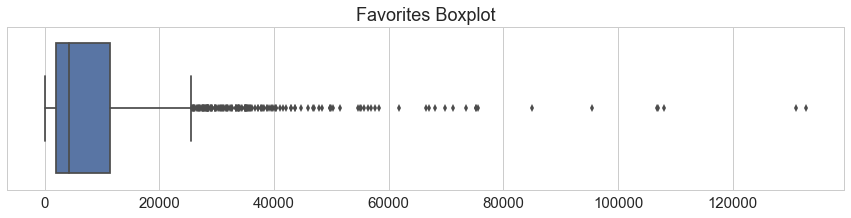

```python
# All favorites in a boxplot
plt.figure(figsize=(15,3))
sns.set(style="whitegrid", font_scale=1.5)
sns.boxplot(x=df.favorites);
plt.title('Favorites Boxplot', fontsize=18);
plt.xlabel('');
```

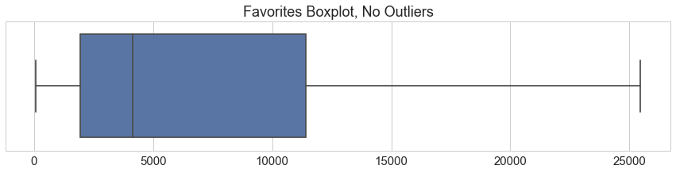

```python
# Shows favorites but with outliers removed
plt.figure(figsize=(15,3))
sns.set(style="whitegrid", font_scale=1.5)
sns.boxplot(x=df.favorites, showfliers=False);
plt.title('Favorites Boxplot, No Outliers', fontsize=18);
plt.xlabel('');
```

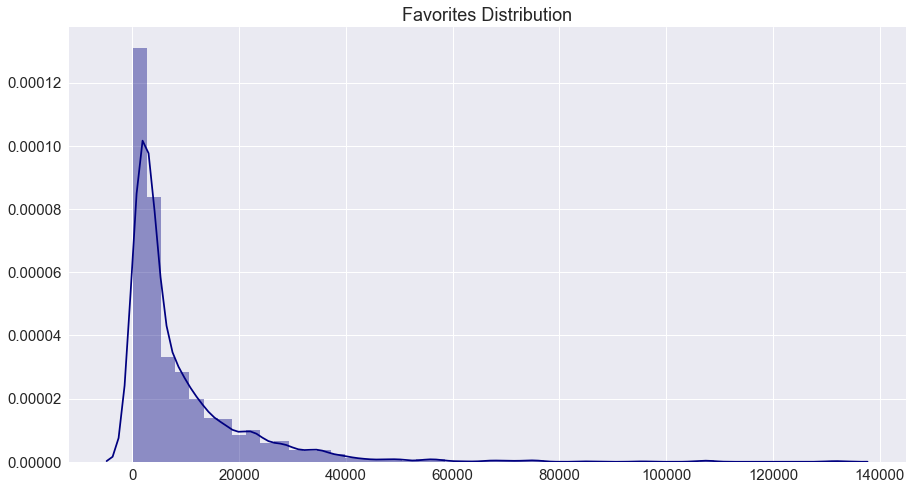

```python
plt.figure(figsize=(15,8))
sns.set(style="darkgrid", font_scale=1.5)
sns.distplot(df.favorites, color="navy");
plt.xlabel('');
plt.title('Favorites Distribution', fontsize=18);
```

The `favorites` data is severely right skewed. The bulk of the data falls between 1957 and 11,416 favorites. But there are clearly some tweets that 'went viral' and got a lot more views and thus more favorites.

Back to Top

### Retweets Data

```python
df.retweets.describe()
```

```
count    1949.000000
mean     2784.492560
std      4709.940601
min      16.000000
25%      624.000000
50%      1360.000000
75%      3240.000000
max      79515.000000
Name: retweets, dtype: float64
```

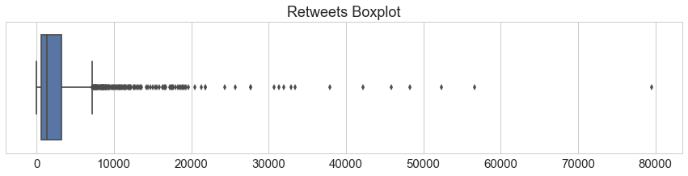

```python
# All retweets in a boxplot
plt.figure(figsize=(15,3))
sns.set(style="whitegrid", font_scale=1.5)
sns.boxplot(x=df.retweets);
plt.title('Retweets Boxplot', fontsize=18);
plt.xlabel('');
```

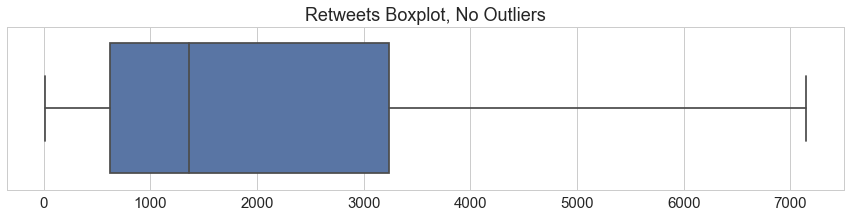

```python
# All retweets in a boxplot
plt.figure(figsize=(15,3))
sns.set(style="whitegrid", font_scale=1.5)
sns.boxplot(x=df.retweets, showfliers=False);
plt.title('Retweets Boxplot, No Outliers', fontsize=18);
plt.xlabel('');
```

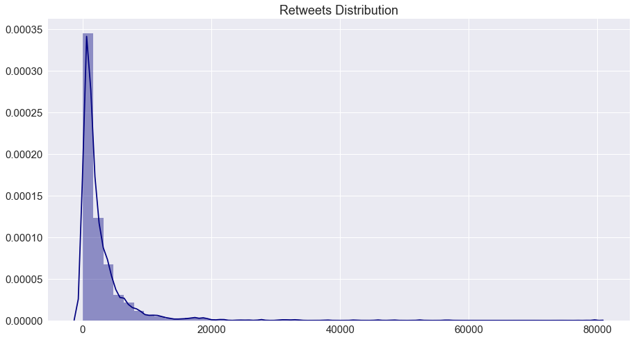

```python
plt.figure(figsize=(15,8))
sns.set(style="darkgrid", font_scale=1.5)
sns.distplot(df.retweets, color="navy");
plt.xlabel('');
plt.title('Retweets Distribution', fontsize=18);
```

The `retweet` data is severely right skewed as well. The bulk of the data falls between 624 and 3240 retweets.

Back to Top

### Name Data

```python
namevc = df['name'].value_counts()
```

```python
namevc[namevc > 4], namevc[namevc > 4].count()
```

```
(Charlie    11
 Lucy       10
 Oliver     10
 Cooper     10
 Tucker     9
 Penny      9
 Winston    8
 Sadie      8
 Lola       7
 Toby       7
 Daisy      7
 Bella      6
 Bo         6
 Jax        6
 Stanley    6
 Koda       6
 Bailey     5
 Leo        5
 Dave       5
 Buddy      5
 Louis      5
 Oscar      5
 Rusty      5
 Milo       5
 Chester    5
 Scout      5
 Name: name, dtype: int64, 26)
```

Back to Top

### Rating Numerators

```python
df.rating_numerator.value_counts()
```

```
12    446
10    417
11    392
13    253
9     149
8     95
7     51
14    33
5     33
6     32
3     19
4     15
2     9
1     4
0     1
Name: rating_numerator, dtype: int64
```

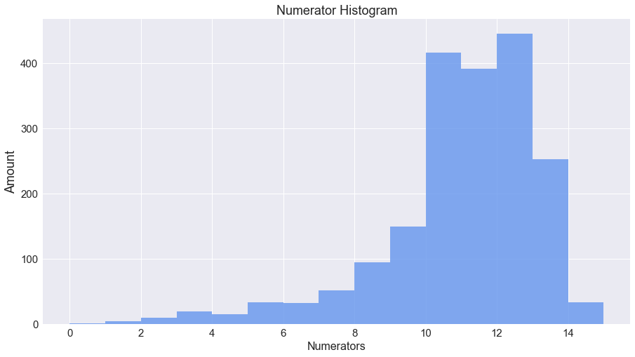

```python
plt.figure(figsize=(15,8))
sns.set(style="darkgrid", font_scale=1.5)
plt.hist(df['rating_numerator'], bins=np.arange(0, 15.1, 1),alpha=0.8 ,color='cornflowerblue')
plt.xlabel('Numerators', fontsize=16);
plt.ylabel('Amount', fontsize=18);
plt.title('Numerator Histogram');
```

The bulk of numerators fall between 10 and 13 (inclusive).

Back to Top

### Prediction Data

I do not trust the prediction data because I spot checked quite a few and I saw quite a few errors, even with a decent confidence interval. But I am going to go on the assumption that we trust the data.

I am setting the standard that I'm only going to work with data that has a 50% or higher confidence interval.

```python
df[df['p1_conf'] > .5].shape
```

```
(1161, 21)
```

```python
df[df['p2_conf'] > .5].shape
```

```
(0, 21)
```

```python
df[df['p3_conf'] > .5].shape
```

```
(0, 21)
```

```python
# Top 25 dog breeds by count
breeds = df.p1.value_counts()[:25]
```

```python
breeds
```

```
golden retriever             134
labrador retriever           91
pembroke                     88
chihuahua                    78
pug                          54
chow                         41
samoyed                      40
toy poodle                   37
pomeranian                   37
malamute                     29
cocker spaniel               27
french bulldog               26
chesapeake bay retriever     23
seat belt                    21
miniature pinscher           21
german shepherd              20
staffordshire bullterrier    19
siberian husky               19
shetland sheepdog            18
eskimo dog                   18
cardigan                     17
shih-tzu                     17
maltese dog                  17
beagle                       17
rottweiler                   16
Name: p1, dtype: int64
```

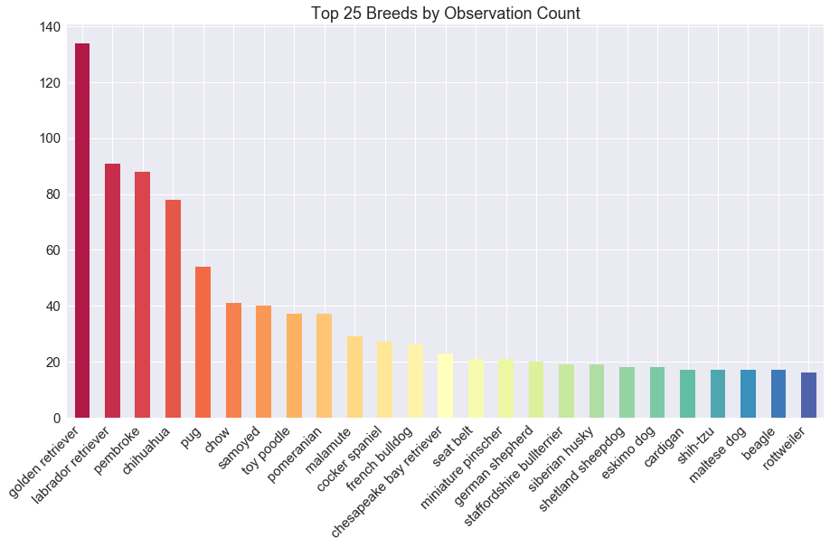

```python
plt.figure(figsize=(15,8))
sns.set(style="darkgrid", font_scale=1.5)
sns.set_palette(sns.color_palette('Spectral', 25))
breeds.plot(kind='bar');
plt.xticks(rotation=45, horizontalalignment="right");
plt.title('Top 25 Breeds by Observation Count', fontsize=18);
```

The top 5 breeds are:

1. Golden Retriever
2. Labrador Retriever
3. Pembroke
4. Chihuahua
5. Pug

Back to Top

## Bivariate Analysis

### Favorites vs Retweets

I want to compare `favorites` and `retweets` to see how they align. However, since they are so severely skewed, I am going to change them to a log10 scale.

```python
log = df.copy()
```

```python
log['favorites'] = np.log10(log['favorites'])
```

```python
log['retweets'] = np.log10(log['retweets'])
```

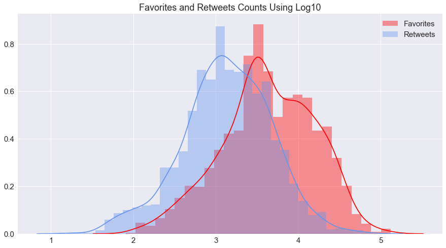

```python
plt.figure(figsize=(15, 8))
sns.set(style="darkgrid", font_scale=1.5)
sns.distplot(log.favorites, color="red", label="Favorites");
sns.distplot(log.retweets, color="cornflowerblue", label="Retweets");
plt.title('Favorites and Retweets Counts Using Log10')
plt.legend();
plt.xlabel('');
```

Favorites and Retweets have similar distributions when scaled to log10. Recall, however, that their 75th percentile is quite different; around 3200 for retweets, while favorites were close to 11,500.

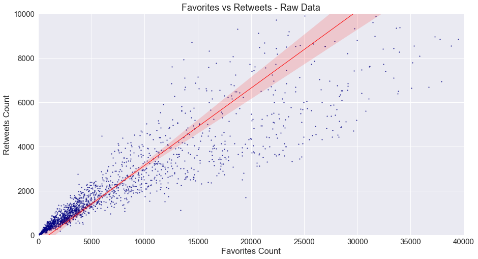

```python
# Scatter plot of favorites and retweets
plt.figure(figsize=(15, 8))
sns.set(style="darkgrid", font_scale=1.5)
sns.regplot(df.favorites, df.retweets, color='navy', scatter_kws={'s':5}, line_kws={'color':'red', 'lw':1})
plt.xlim(0, 40000)
plt.ylim(0, 10000)
plt.xlabel('Favorites Count')
plt.ylabel('Retweets Count')
plt.title('Favorites vs Retweets - Raw Data');
```

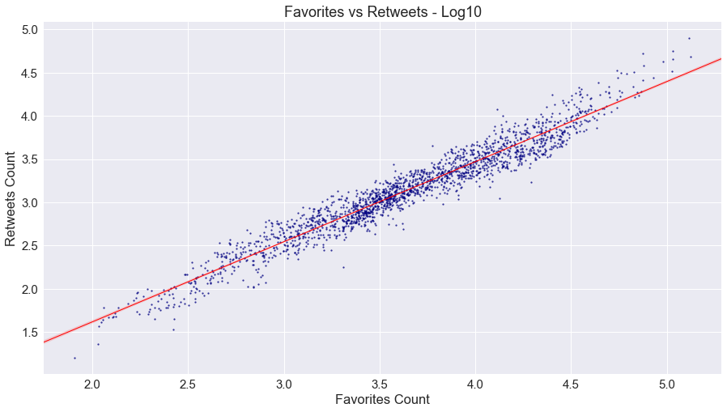

```python
# Scatter plot of favorites and retweets in log10
plt.figure(figsize=(15, 8))
sns.set(style="darkgrid", font_scale=1.5)
sns.regplot(log.favorites, log.retweets, color='navy', scatter_kws={'s':5}, line_kws={'color':'red', 'lw':1});
plt.xlabel('Favorites Count')
plt.ylabel('Retweets Count')
plt.title('Favorites vs Retweets - Log10');
```

There is clearly a positive linear relationship with favorites and retweets.

Back to Top

### Breeds and Favorites

I want to compare favorite counts per breed. For this I'm going to drop all p1_dogs that are False, and I'm going to limit it to the top 25.

```python
bf = df.copy()
```

```python
bf.shape
```

```
(1949, 21)
```

```python
# Drops rows where p1_dog is false
bf = bf.loc[bf['p1_dog'] == True]
```

```python
# Dropped about 500 rows
bf.shape
```

```
(1446, 21)
```

```python
#bf[~bf.p1.str.contains('web site')]
```

```python
# Set up a groupby on p1 and favorites and limit the results to the 25 most
bf = bf.groupby(['p1'])['favorites'].sum().sort_values(ascending=False)[:25]
```

```python
bf
```

```
p1
golden retriever             1663838
labrador retriever           1104820
pembroke                     994755
chihuahua                    673526
samoyed                      542991
french bulldog               465738
chow                         404241
pug                          320223
cocker spaniel               315825
pomeranian                   278818
cardigan                     260287
toy poodle                   250648
malamute                     249179
chesapeake bay retriever     232997
eskimo dog                   216028
german shepherd              203093
lakeland terrier             198198
miniature pinscher           187889
staffordshire bullterrier    187099
basset                       180258
great pyrenees               177847
shetland sheepdog            154553
english springer             140915
siberian husky               137408
flat-coated retriever        134333
Name: favorites, dtype: int64
```

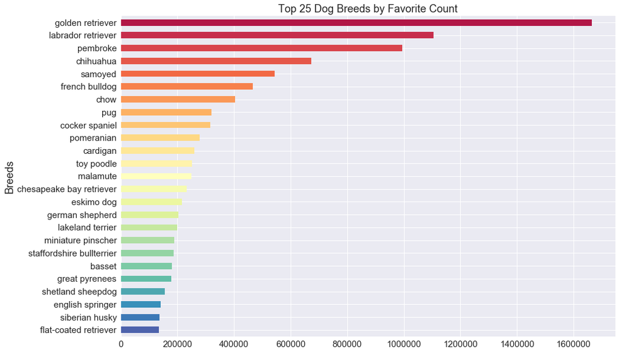

```python
# Plotting with original data
sns.set_palette(sns.color_palette('Spectral', 25))
bf.plot(kind='barh', figsize=(15,10));
plt.gca().invert_yaxis()
plt.ylabel('Breeds', fontsize=18);
plt.title('Top 25 Dog Breeds by Favorite Count', fontsize=18);
```

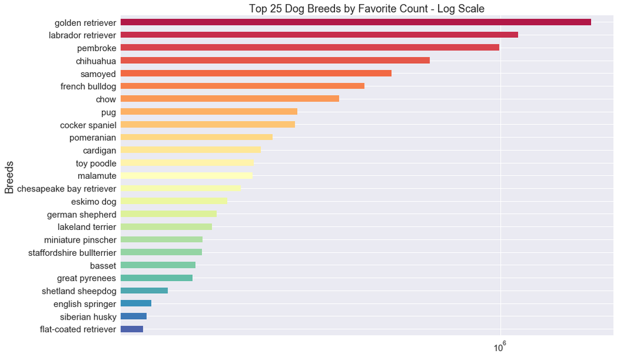

```python
# Plotting using a log scale to get a better understanding of the data
sns.set_palette(sns.color_palette('Spectral', 25))
bf.plot(kind='barh', figsize=(15,10), logx=True);
plt.gca().invert_yaxis()
plt.ylabel('Breeds', fontsize=18);
plt.title('Top 25 Dog Breeds by Favorite Count - Log Scale', fontsize=18);
```

```python
bf[:10]
```

```
p1
golden retriever      1663838
labrador retriever    1104820
pembroke              994755
chihuahua             673526
samoyed               542991
french bulldog        465738
chow                  404241
pug                   320223
cocker spaniel        315825
pomeranian            278818
Name: favorites, dtype: int64
```

```python
breeds[:10]
```

```
golden retriever      134
labrador retriever    91
pembroke              88
chihuahua             78
pug                   54
chow                  41
samoyed               40
toy poodle            37
pomeranian            37
malamute              29
Name: p1, dtype: int64
```

The Golden Retriever is clearly the favorite breed. Just looking at the top 10, the top breeds by favorites does not line up exactly with the number of times those breeds are in listed in the p1 data. The top 4 are the same, but pug does not have as many likes as the Samoyed, French Bulldog, and Chow.

Back to Top

```python
# Shows all the dataframes used in this document
%whos DataFrame
```

[output not shown]

# Resources

Tidy Data  
https://cran.r-project.org/web/packages/tidyr/vignettes/tidy-data.html

Checking for commonalities using Set and Intersection  
https://docs.python.org/3.7/library/stdtypes.html#set  
https://docs.python.org/3.7/library/stdtypes.html?highlight=intersection#frozenset.intersection

How to find stings that are a certain case (upper, lower, mix)  
https://stackoverflow.com/questions/8222855/check-if-string-is-upper-lower-or-mixed-case-in-python

How to see if strings in a list are in a dataframe column  
https://stackoverflow.com/questions/17972938/check-if-string-in-pandas-dataframe-column-is-in-list

Getting parts of a URL using regex  
https://stackoverflow.com/questions/27745/getting-parts-of-a-url-regex

List comprehension  
https://www.pythonforbeginners.com/basics/list-comprehensions-in-python

How to plot a Pandas series  
https://pandas.pydata.org/pandas-docs/stable/reference/api/pandas.Series.plot.html

How to invert a horizontal bar chart in a Pandas series plot  
https://stackoverflow.com/questions/34076177/matplotlib-horizontal-bar-chart-barh-is-upside-down

How to select rows from a dataframe based on values in a column  
https://stackoverflow.com/questions/17071871/select-rows-from-a-dataframe-based-on-values-in-a-column-in-pandas

Back to Top